# Project for Machine Learning

Carol

December 17, 2015

# Introduction

The issue which we investigate is the ability of wearable technology to determine if the user is preforming an exercise correctly. In particular our data contains measurements from wearable devices which measure various aspects of activity. There are 6 participants for whom data is collected while preforming a dumbbell lift in 5 different ways.

The goal of your project is to predict the manner in which they did the exercise. This is the “classe” variable in the training set which contains indicators {A,B,C,D,E}, according to the specification doing the exercise correctly (Class A), throwing the elbows to the front (Class B), lifting the dumbbell only halfway (Class C), lowering the dumbbell only halfway (Class D) and throwing the hips to the front (Class E). A corresponds to the correct way to do the exercise while the other 4 classes are common mistakes. Below is the source for the data. Velloso, E.; Bulling, A.; Gellersen, H.; Ugulino, W.; Fuks, H. Qualitative Activity Recognition of Weight Lifting Exercises. Proceedings of 4th International Conference in Cooperation with SIGCHI (Augmented Human ’13) . Stuttgart, Germany: ACM SIGCHI, 2013.

Read more: http://groupware.les.inf.puc-rio.br/har#ixzz3vLL1gPmJ

# Exploration of Data

Some of the variables have mostly “NA”s in the columns and others are mostly blank. These columns were eliminated from the data.

Several models were tested as predictors. The two with the best results were Random Forests and Boosting Trees. But the Random Forests was the best. See the details below.

# Appendix

```r
library(caret)
library(doMC)
setwd("/Users/carollawrence/Coursera/DataScience/MachineLearning/Project")
data <- read.csv("data/pml-training.csv")
dim(data)
```

```
## [1] 19622   160
```

Many of the columns contain mostly “NA”. Count them and remove columns that are mostly “NA”.

```r
NAS <- vector(,160)
good <- vector(,160)
j = 0
for(i in 1:160){
      NAS[i] = sum(is.na(data[,i]))
      good[i] = 0
      nas <- sum(is.na(data[,i]))
      if(nas == 0){
            good[j]=i
            j = j+1
      }
}
NAS
```

```
##   [1]     0     0     0     0     0     0     0     0     0     0     0
##  [12]     0     0     0     0     0     0 19216 19216     0 19216 19216
##  [23]     0 19216 19216     0 19216 19216 19216 19216 19216 19216 19216
##  [34] 19216 19216 19216     0     0     0     0     0     0     0     0
##  [45]     0     0     0     0     0 19216 19216 19216 19216 19216 19216
##  [56] 19216 19216 19216 19216     0     0     0     0     0     0     0
##  [67]     0     0     0     0     0     0     0     0 19216 19216 19216
##  [78] 19216 19216 19216 19216 19216 19216     0     0     0     0     0
##  [89]     0     0     0     0 19216 19216     0 19216 19216     0 19216
## [100] 19216     0     0 19216 19216 19216 19216 19216 19216 19216 19216
## [111] 19216 19216     0     0     0     0     0     0     0     0     0
## [122]     0     0     0     0     0     0     0     0     0 19216 19216
## [133]     0 19216 19216     0 19216 19216     0     0 19216 19216 19216
## [144] 19216 19216 19216 19216 19216 19216 19216     0     0     0     0
## [155]     0     0     0     0     0     0
```

```r
good
```

```
##   [1]   2   3   4   5   6   7   8   9  10  11  12  13  14  15  16  17  20
##  [18]  23  26  37  38  39  40  41  42  43  44  45  46  47  48  49  60  61
##  [35]  62  63  64  65  66  67  68  69  70  71  72  73  74  84  85  86  87
##  [52]  88  89  90  91  92  95  98 101 102 113 114 115 116 117 118 119 120
##  [69] 121 122 123 124 125 126 127 128 129 130 133 136 139 140 151 152 153
##  [86] 154 155 156 157 158 159 160   0   0   0   0   0   0   0   0   0   0
## [103]   0   0   0   0   0   0   0   0   0   0   0   0   0   0   0   0   0
## [120]   0   0   0   0   0   0   0   0   0   0   0   0   0   0   0   0   0
## [137]   0   0   0   0   0   0   0   0   0   0   0   0   0   0   0   0   0
## [154]   0   0   0   0   0   0   0
```

```r
data1 <- data[,good]
dim(data1)
```

```
## [1] 19622    92
```

Some of the columns contain vary few values. Find these.

```r
k = 0
good <- vector(,92)
mostlyZero <- vector(,92)
for(j in 1:92){
      count = 0
      mostlyZero[j] = 0
      good[j]=0
      for(i in 1:19622){
            if(data1[i,j] == ""){ count = count + 1}
      }
      mostlyZero[j] = count
      if(count == 0){good[k] = j; k=k+1}
}
mostlyZero
```

```
##  [1]     0     0     0     0     0     0     0     0     0     0 19216
## [12] 19216 19216 19216 19216 19216 19216 19216 19216     0     0     0
## [23]     0     0     0     0     0     0     0     0     0     0     0
## [34]     0     0     0     0     0     0     0     0 19216 19216 19216
## [45] 19216 19216 19216     0     0     0 19216 19216 19216 19216 19216
## [56] 19216 19216 19216 19216     0     0     0     0     0     0     0
## [67]     0     0     0     0     0     0 19216 19216 19216 19216 19216
## [78] 19216 19216 19216 19216     0     0     0     0     0     0     0
## [89]     0     0     0     0
```

Remove these mostly empty columns.

```r
good
```

```
##  [1]  2  3  4  5  6  7  8  9 10 20 21 22 23 24 25 26 27 28 29 30 31 32 33
## [24] 34 35 36 37 38 39 40 41 48 49 50 60 61 62 63 64 65 66 67 68 69 70 71
## [47] 72 82 83 84 85 86 87 88 89 90 91 92  0  0  0  0  0  0  0  0  0  0  0
## [70]  0  0  0  0  0  0  0  0  0  0  0  0  0  0  0  0  0  0  0  0  0  0  0
```

```r
data2 <- data1[,good]
head(data2,1)
```

```
##   raw_timestamp_part_1 raw_timestamp_part_2   cvtd_timestamp new_window
## 1           1323084231               788290 05/12/2011 11:23         no
##   num_window roll_belt pitch_belt yaw_belt total_accel_belt gyros_belt_x
## 1         11      1.41       8.07    -94.4                3            0
##   gyros_belt_y gyros_belt_z accel_belt_x accel_belt_y accel_belt_z
## 1            0        -0.02          -21            4           22
##   magnet_belt_x magnet_belt_y magnet_belt_z roll_arm pitch_arm yaw_arm
## 1            -3           599          -313     -128      22.5    -161
##   total_accel_arm gyros_arm_x gyros_arm_y gyros_arm_z accel_arm_x
## 1              34           0           0       -0.02        -288
##   accel_arm_y accel_arm_z magnet_arm_x magnet_arm_y magnet_arm_z
## 1         109        -123         -368          337          516
##   roll_dumbbell pitch_dumbbell yaw_dumbbell total_accel_dumbbell
## 1      13.05217        -70.494    -84.87394                   37
##   gyros_dumbbell_x gyros_dumbbell_y gyros_dumbbell_z accel_dumbbell_x
## 1                0            -0.02                0             -234
##   accel_dumbbell_y accel_dumbbell_z magnet_dumbbell_x magnet_dumbbell_y
## 1               47             -271              -559               293
##   magnet_dumbbell_z roll_forearm pitch_forearm yaw_forearm
## 1               -65         28.4         -63.9        -153
##   total_accel_forearm gyros_forearm_x gyros_forearm_y gyros_forearm_z
## 1                  36            0.03               0           -0.02
##   accel_forearm_x accel_forearm_y accel_forearm_z magnet_forearm_x
## 1             192             203            -215              -17
##   magnet_forearm_y magnet_forearm_z classe
## 1              654              476      A
```

Remove variables - raw_timestamp_part_1, raw_timestamp_part_2, cvtd_timestamp new_window, num_window. These do not seem to contribute to understanding how well and exercise is being done.

```r
data3 <- data2[,!(names(data2) %in% c("raw_timestamp_part_1", "raw_timestamp_part_2","cvtd_timestamp","new_window", "num_window"))]
dim(data3)
```

```
## [1] 19622    53
```

Variables left to build model roll_belt, pitch_belt, yaw_belt, total_accel_belt, gyros_belt_x, gyros_belt_y, gyros_belt_z accel_belt_x, accel_belt_y, accel_belt_z magnet_belt_x, magnet_belt_y, magnet_belt_z roll_arm, pitch_arm, yaw_arm, total_accel_arm gyros_arm_x,gyros_arm_y, gyros_arm_z accel_arm_x, accel_arm_y, accel_arm_z magnet_arm_x, magnet_arm_y, magnet_arm_z roll_dumbbell, pitch_dumbbell, yaw_dumbbell, total_accel_dumbbell gyros_dumbbell_x, gyros_dumbbell_y, gyros_dumbbell_z accel_dumbbell_x, accel_dumbbell_y, accel_dumbbell_z magnet_dumbbell_x, magnet_dumbbell_y, magnet_dumbbell_z roll_forearm, pitch_forearm, yaw_forearm, total_accel_forearm gyros_forearm_x, gyros_forearm_y, gyros_forearm_z accel_forearm_x, accel_forearm_y, accel_forearm_z magnet_forearm_x, magnet_forearm_y, magnet_forearm_z classe

Divide the data into a training and a testing set, with 75% of data in the training set.

```r
registerDoMC(cores = 4)
set.seed(489)
inTrain <- createDataPartition(y=data3$classe, p=0.75, list=FALSE)
training <- data3[inTrain,]
testing <- data3[-inTrain,]
dim(training)
```

```
## [1] 14718    53
```

Check the proportions of each classe is contained in the training and testing sets.

```
## [1] 0.2843747 0.1935073 0.1743961 0.1638977 0.1838243
```

```
## [1] 0.2843457 0.1935046 0.1744123 0.1638810 0.1838565
```

```
## [1] 0.2844617 0.1935155 0.1743475 0.1639478 0.1837276
```

Training and testing are in the same proportion as the classes in the original data.

Boosting with Trees

```r
set.seed(3456)
fitControl <- trainControl(method = "repeatedcv",number = 5,repeats=10)
modelFitgbm <- train(training$classe~.,data=training,method="gbm",trControl = fitControl,verbose=FALSE)
confusionMatrix(testing$classe,predict(modelFitgbm,testing))
```

```
## Confusion Matrix and Statistics
##
##           Reference
## Prediction    A    B    C    D    E
##          A 1367   14    6    6    2
##          B   29  884   33    3    0
##          C    0   26  820    8    1
##          D    1    1   23  775    4
##          E    2   15    4    8  872
##
## Overall Statistics
##
##                Accuracy : 0.9621
##                  95% CI : (0.9563, 0.9672)
##     No Information Rate : 0.2853
##     P-Value [Acc > NIR] : < 2.2e-16
##
##                   Kappa : 0.952
##  Mcnemar's Test P-Value : 7.42e-06
##
## Statistics by Class:
##
##                      Class: A Class: B Class: C Class: D Class: E
## Sensitivity            0.9771   0.9404   0.9255   0.9688   0.9920
## Specificity            0.9920   0.9836   0.9913   0.9929   0.9928
## Pos Pred Value         0.9799   0.9315   0.9591   0.9639   0.9678
## Neg Pred Value         0.9909   0.9858   0.9837   0.9939   0.9983
## Prevalence             0.2853   0.1917   0.1807   0.1631   0.1792
## Detection Rate         0.2788   0.1803   0.1672   0.1580   0.1778
## Detection Prevalence   0.2845   0.1935   0.1743   0.1639   0.1837
## Balanced Accuracy      0.9846   0.9620   0.9584   0.9808   0.9924
```

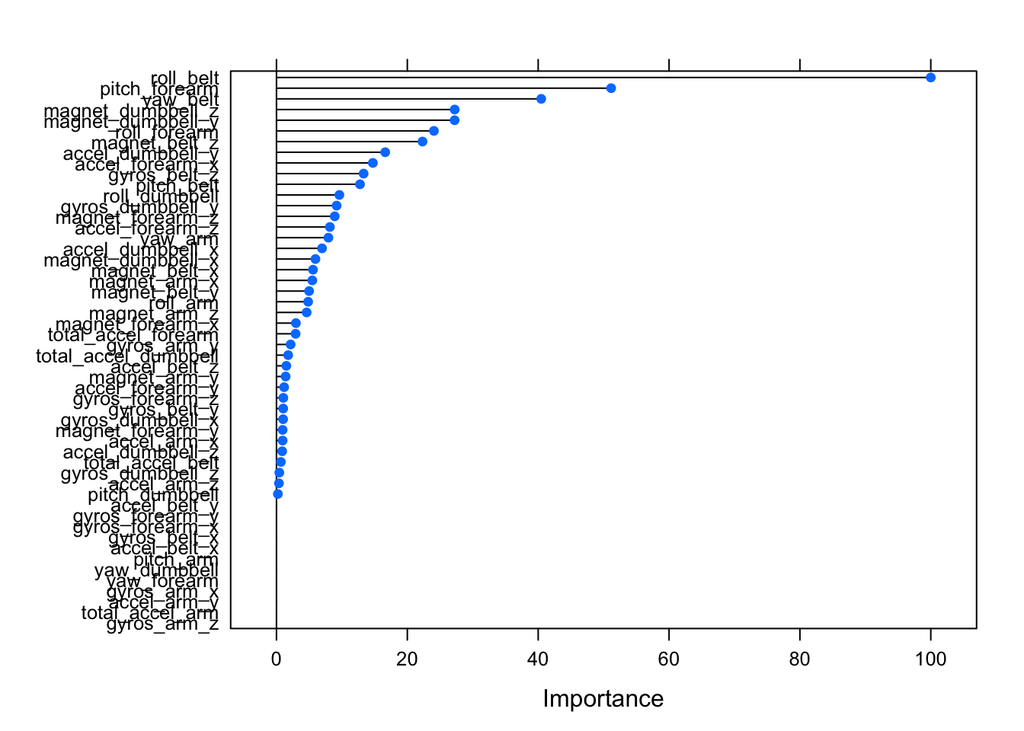

```r
plot(varImp(modelFitgbm, top=20))
```

Random Forest

```r
set.seed(3456)
fitControl <- trainControl(method = "repeatedcv", number=5, repeats=10)
modelFitrf <- train(classe~., data = training, method="rf",trControl=fitControl)
confusionMatrix(testing$classe,predict(modelFitrf,testing))
```

```
## Confusion Matrix and Statistics
##
##           Reference
## Prediction    A    B    C    D    E
##          A 1395    0    0    0    0
##          B    6  940    3    0    0
##          C    0    8  845    2    0
##          D    0    0   22  781    1
##          E    0    0    0    0  901
##
## Overall Statistics
##
##                Accuracy : 0.9914
##                  95% CI : (0.9884, 0.9938)
##     No Information Rate : 0.2857
##     P-Value [Acc > NIR] : < 2.2e-16
##
##                   Kappa : 0.9892
##  Mcnemar's Test P-Value : NA
##
## Statistics by Class:
##
##                      Class: A Class: B Class: C Class: D Class: E
## Sensitivity            0.9957   0.9916   0.9713   0.9974   0.9989
## Specificity            1.0000   0.9977   0.9975   0.9944   1.0000
## Pos Pred Value         1.0000   0.9905   0.9883   0.9714   1.0000
## Neg Pred Value         0.9983   0.9980   0.9938   0.9995   0.9998
## Prevalence             0.2857   0.1933   0.1774   0.1597   0.1839
## Detection Rate         0.2845   0.1917   0.1723   0.1593   0.1837
## Detection Prevalence   0.2845   0.1935   0.1743   0.1639   0.1837
## Balanced Accuracy      0.9979   0.9946   0.9844   0.9959   0.9994
```

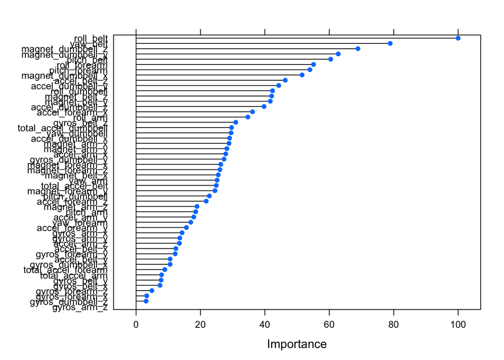

```r
plot(varImp(modelFitrf, top=20))
```

```r
pred1 <- predict(modelFitrf,testing)
pred2 <- predict(modelFitgbm,testing)
```

The Rain Forest model has the best accuracy. To check how much each of the models differs we compute the percent of agreement.

```r
length(pred1)
```

```
## [1] 4904
```

```r
length(pred2)
```

```
## [1] 4904
```

```r
count = 0
for(i in 1:length(pred1)){
      if(pred1[i] == pred2[i]){count = count + 1}
}
count/length(pred1)
```

```
## [1] 0.9651305
```

The accuracy of the Rain Forest model is 0.9914 while the accuracy of the Boosting model is 0.9621 and the two agree on 0.9651 of the classes.

Test the data pml-testing.csv with both models.

```r
data.testing <- read.csv("/Users/carollawrence/Coursera/DataScience/MachineLearning/Project/data/pml-testing.csv")
predict(modelFitrf,data.testing)
```

```
##  [1] B A B A A E D B A A B C B A E E A B B B
## Levels: A B C D E
```

```r
predict(modelFitgbm,data.testing)
```

```
##  [1] B A B A A E D B A A B C B A E E A B B B
## Levels: A B C D E
```